# Regression Discontinuity | Codethrough

The treatment effect is the same magnitude — the sign just reflects which direction you’re jumping/falling when moving from left to right across the cutoff.

### The Golden Rule: Plot to Verify Your Interpretation

If you’re ever unsure whether your `rdrobust()` coefficient makes sense, **plot it using `rdplot()`**. This is the most reliable way to verify your interpretation.

Remember: `rdrobust()` always calculates **RIGHT minus LEFT**. So when you look at your `rdplot()` output, ask yourself:

> “If I start on the LEFT side and move to the RIGHT side at the cutoff, does the outcome go UP or DOWN?”

- If it goes **UP** (right side is higher), `rdrobust()` returns a **positive** coefficient - If it goes **DOWN** (right side is lower), `rdrobust()` returns a **negative** coefficient

Then connect this to your research question:

- Which side is your **treatment** group on? - If treatment is on the **higher** side at the cutoff, treatment **helped** - If treatment is on the **lower** side at the cutoff, treatment **hurt**

The visual from `rdplot()` never lies — it shows you exactly what’s happening at the cutoff. The coefficient sign is just a consequence of the package’s right-minus-left convention.

## Comparing lm() vs rdrobust()

Let’s put our estimates side by side:

`r cat("Comparison of Estimation Approaches:\n\n", "Method | Treatment Effect | Notes\n", "----------------|------------------|---------------------------\n", sprintf("lm() with RDD | %.2f | Uses all data\n", coef(rdd_interaction)["treat"]), sprintf("rdrobust() | %.2f | Optimal bandwidth, robust SE\n", rd_model$coef[1]))`

`## Comparison of Estimation Approaches: ## ## Method | Treatment Effect | Notes ## ----------------|------------------|--------------------------- ## lm() with RDD | 6.04 | Uses all data ## rdrobust() | 7.41 | Optimal bandwidth, robust SE`

Notice how the `lm()` and `rdrobust()` estimates are kind of close to each other, but both are much smaller than the naive estimate we saw at the beginning when we ran the t-test? That’s because the naive estimate was contaminated by selection bias - good candidates both win AND do well next time.

**Which should you trust?** For inference, use `rdrobust()`. It’s designed specifically for RDD and handles all the technical details correctly.

# Understanding the Counterfactual

## What Would Have Happened?

The power of RDD is that it lets us answer counterfactual questions. For a candidate who barely won, we can estimate what their next-election performance would have been if they had barely lost instead.

Using our `lm()` coefficients, let’s walk through this:

``` r # Predicted vote share for a LOSER at the cutoff (margin = 0) # Treatment = 0, margin = 0 # Simplifies to just b0 predicted_loser <- b0 + b1 * 0 + b2 * 0

# Predicted vote share for a WINNER at the cutoff (margin = 0) # Treatment = 1, margin = 0 # Simplifies to b0 + b1 predicted_winner <- b0 + b1 * 1 + b2 * 0

# What is the predicted vote share for a winner, that won by 5% margin? adhoc <- b0 + b1 * 1 + b2 * 5

# what is the predicted vote share for a loser that lost by 8% margin? adhoc_2 <- b0 + b1 * 0 + b2 * -8

adhoc_2 ```

`## (Intercept) ## 43.1738`

`r cat("Counterfactual Analysis at the Cutoff:\n\n", "A candidate who BARELY LOST (margin ~ 0):\n", " Predicted next-election vote share:", round(predicted_loser, 2), "%\n\n", "A candidate who BARELY WON (margin ~ 0):\n", " Predicted next-election vote share:", round(predicted_winner, 2), "%\n\n", "The difference (Treatment Effect):\n", " ", round(predicted_winner, 2), "-", round(predicted_loser, 2), "=", round(predicted_winner - predicted_loser, 2), "percentage points\n")`

`## Counterfactual Analysis at the Cutoff: ## ## A candidate who BARELY LOST (margin ~ 0): ## Predicted next-election vote share: 44.9 % ## ## A candidate who BARELY WON (margin ~ 0): ## Predicted next-election vote share: 50.95 % ## ## The difference (Treatment Effect): ## 50.95 - 44.9 = 6.04 percentage points`

This confirms that our treatment coefficient ($\beta_1$) is exactly the difference in predicted outcomes at the cutoff - the causal effect of winning.

## The Local Average Treatment Effect (LATE)

There’s an important caveat: our treatment effect estimate is **local** to the cutoff. We’ve estimated the incumbency advantage for candidates in close elections (those right around a `margin` of 0).

This might not be the same as the incumbency advantage for candidates in landslide elections. A candidate who won with 70% of the vote might experience a different incumbency boost than a candidate who won with 50.1%.

RDD gives us the **Local Average Treatment Effect (LATE)** - the effect for observations right at the cutoff. This is still incredibly valuable, but be careful about generalizing to the entire population.

# Checking Assumptions

RDD requires certain assumptions to hold. Let’s check the most important ones.

## Is Our Design Actually Sharp?

In a sharp RDD, the cutoff perfectly determines treatment. Let’s verify this by plotting treatment status against the running variable:

`r # Plot treatment status against margin plot(senate$margin, senate$treat, pch = 19, col = rgb(0.2, 0.2, 0.6, 0.3), xlab = "Vote Margin (%)", ylab = "Won Election (Treatment)", main = "Checking for Sharp RDD: Treatment Status by Running Variable", yaxt = "n") axis(2, at = c(0, 1), labels = c("Lost (0)", "Won (1)")) abline(v = 0, col = "#8C1D40", lwd = 2, lty = 2)`

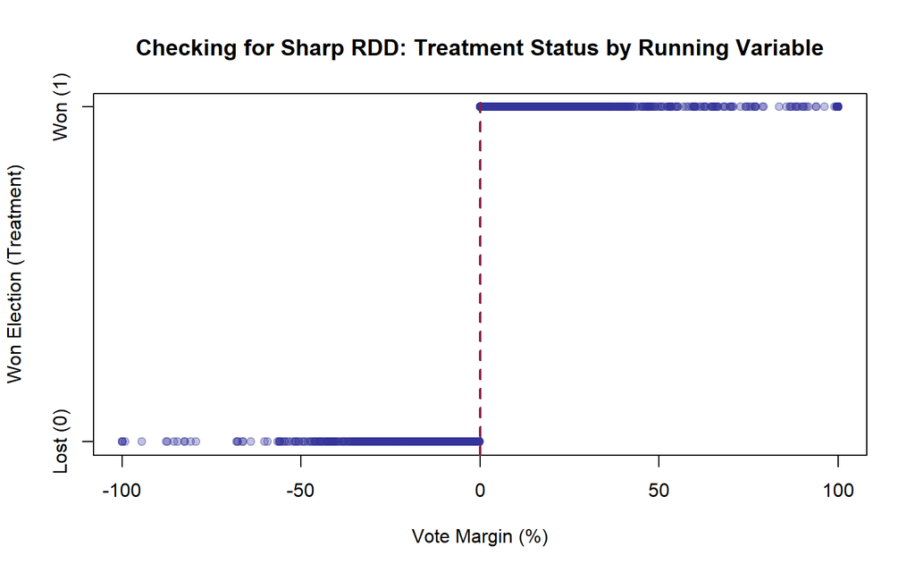

Perfect! Everyone with margin > 0 has treatment = 1 (won), and everyone with margin < 0 has treatment = 0 (lost). This is exactly what a sharp RDD should look like - a clean step at the cutoff.

If we saw gradual change (some winners below the cutoff, some losers above), that would indicate a fuzzy design requiring different methods.

## Could People Manipulate Their Score?

A key assumption of RDD is that people can’t precisely control which side of the cutoff they land on. If they could, the local randomization logic breaks down.

For elections, manipulation would mean candidates can precisely control their vote share to land just above 50%. This is unrealistic - elections involve millions of voters and lots of uncertainty.

One way to check for manipulation is to look at the **density** of the running variable around the cutoff. If people are manipulating, we’d expect to see bunching just above the cutoff (everyone trying to barely win).

``` r # Histogram of margin around the cutoff hist(senate$margin[senate$margin > -30 & senate$margin < 30], breaks = 30, main = “Density of Vote Margin Near Cutoff”, xlab = “Vote Margin (%)”, col = “lightblue”, border = “white”) abline(v = 0, col = “#8C1D40”, lwd = 2, lty = 2)

# Add annotation text(15, 40, “If manipulation were occurring,’d see bunching just above 0”, col = “#8C1D40”, font = 2) ```

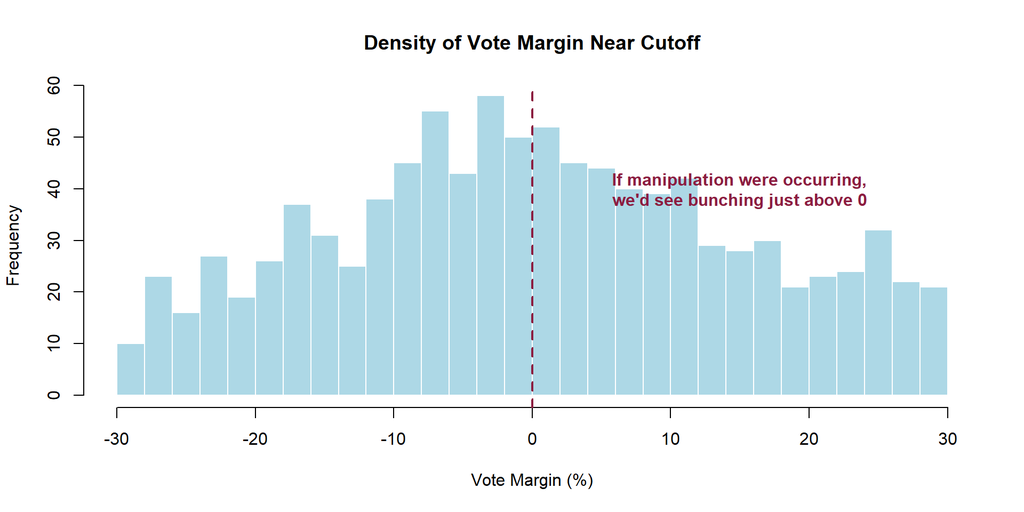

The distribution looks fairly smooth around the cutoff - no obvious spike just above 0. This supports the assumption that candidates aren’t manipulating their vote shares.

For a more formal manipulation test, researchers use the “McCrary density test” which statistically checks for a discontinuity in the density at the cutoff. The `rddensity` package (by the same authors as `rdrobust`) implements this. For our purposes, a visual check with a histogram is sufficient.

## Other Threats

A few other things to consider:

1. **Are there other policies that change at the same cutoff?** If something else changes exactly at 50% (besides incumbency status), we can’t isolate the effect of incumbency alone.

2. **Is the relationship really continuous away from the cutoff?** RDD assumes that without the treatment, the outcome would be continuous at the cutoff. If there’s some other reason for a “jump,” our estimate is contaminated.

For the Senate data, these concerns seem minimal. The 50% threshold only affects who wins - there’s no other policy that kicks in at exactly that point.

# The Final Verdict

## Summary of Findings

`r # Display parallel lines model & interaction model stargazer(rdd_lm, rdd_interaction, type = "text", #type = "html", title = "Comparison: Naive Model vs. RDD Model", column.labels = c("Naive", "RDD"), dep.var.labels = "Vote Share in Next Election", covariate.labels = c("Won Election (Treatment)", "Vote Margin"), omit.stat = c("f", "ser"), digits = 2)`

Comparison: Naive Model vs. RDD Model ===================================================== Dependent variable: —————————- Vote Share in Next Election Naive RDD (1) (2)

Won Election (Treatment) 4.78*** 6.04***  
(0.92) (0.94)

Vote Margin 0.35*** 0.22***  
(0.01) (0.03)

treat:margin 0.17***  
(0.03)

Constant 47.33*** 44.90***  
(0.54) (0.70)

Observations 1,297 1,297  
R2 0.58 0.59  
Adjusted R2 0.58 0.59  
===================================================== Note: *p<0.1; **p<0.05;*** p<0.01

```r
# Display rdrobust model
summary(rd_model)
```

```
## Sharp RD estimates using local polynomial regression.
##
## Number of Obs.                 1297
## BW type                       mserd
## Kernel                   Triangular
## VCE method                       NN
##
## Number of Obs.                  595          702
## Eff. Number of Obs.             360          323
## Order est. (p)                    1            1
## Order bias  (q)                   2            2
## BW est. (h)                  17.754       17.754
## BW bias (b)                  28.028       28.028
## rho (h/b)                     0.633        0.633
## Unique Obs.                     595          665
##
## =====================================================================
##                    Point    Robust Inference
##                 Estimate         z     P>|z|      [ 95% C.I. ]
## ---------------------------------------------------------------------
##      RD Effect     7.414     4.311     0.000     [4.094 , 10.919]
## =====================================================================
```

```r
cat("\nFinal Results Summary:\n\n",
    "Research Question: Does winning a close election give incumbents an advantage?\n\n",
    "RDD Estimate (rdrobust):", round(rd_model$coef[1], 1), "percentage points\n",
    "  95% CI: [", round(rd_model$ci[3,1], 1), ",", round(rd_model$ci[3,2], 1), "]\n\n",
    "Conclusion: Yes! Winning a close Senate election causes approximately a\n",
    round(rd_model$coef[1], 0), "-percentage point boost in the next election's vote share.\n\n",
    "This is the 'incumbency advantage' and it's statistically significant.\n")
```

```
##
## Final Results Summary:
##
##  Research Question: Does winning a close election give incumbents an advantage?
##
##  RDD Estimate (rdrobust): 7.4 percentage points
##    95% CI: [ 4.1 , 10.9 ]
##
##  Conclusion: Yes! Winning a close Senate election causes approximately a
##  7 -percentage point boost in the next election's vote share.
##
##  This is the 'incumbency advantage' and it's statistically significant.
```

## The RDD Workflow

**The RDD Workflow (Use This for Your Lab):**

1. **Understand the setting** - What’s the cutoff? What’s the running variable? Is it sharp or fuzzy?
2. **Create your variables** - Treatment indicator, centered running variable
3. **Run the naive comparison** - Show why simple group comparison is misleading
4. **Run `lm()` model** - Understand the mechanics and interpret coefficients
5. **Run `rdrobust()` model** - Get proper estimates with optimal bandwidth
6. **Check bandwidth sensitivity** - Does your result hold across different bandwidths?
7. **Visualize with `rdplot()`** - Show the discontinuity graphically
8. **Check assumptions** - Sharp design? No manipulation? No other discontinuities?
9. **Interpret the LATE** - Your estimate is local to the cutoff

## Key Takeaways

1. **RDD exploits cutoff-based assignment** - When treatment is determined by whether you’re above or below a threshold, we can estimate causal effects by comparing people right at the cutoff.
2. **Near the cutoff, treatment is as-if random** - A candidate who got 50.1% vs 49.9% are essentially identical except for treatment status.
3. **Use `lm()` to understand, `rdrobust()` to publish** - The basic `lm()` model helps build intuition, but `rdrobust()` handles bandwidth selection, bias correction, and proper inference.
4. **Always check bandwidth sensitivity** - Your results should be stable across reasonable bandwidth choices. If they’re not, be skeptical.
5. **RDD estimates are local** - The treatment effect applies to observations at the cutoff. Be cautious about generalizing to the full population.
6. **Check your assumptions** - Verify sharp assignment, look for manipulation, consider other discontinuities.